# Análisis de Componentes Principales (PCA) — Loberman-Nachum et al. (2019)

2026-06-30

Este script realiza el análisis exploratorio no supervisado de los datos de expresión génica mediante PCA. A diferencia de los papers anteriores, aquí no hay múltiples matrices ómicas ni múltiples puntos de tiempo: hay una única matriz de expresión con 54 muestras y aproximadamente 14.300 genes. El PCA permite visualizar la estructura global de los datos, detectar si celiaquía y controles se separan de forma natural en el espacio de componentes, e identificar posibles fuentes de variabilidad técnica o clínica que puedan confundir los análisis posteriores.

# Carga de librerías y datos

```r
library(tidyverse)
library(PLSandO)
library(knitr)

library(here)
processed_dir <- here("data", "processed", "loberman_nachum")

metadata                 <- readRDS(file.path(processed_dir, "metadata.rds"))
expression_log_data      <- readRDS(file.path(processed_dir, "expression_log_data.rds"))
gene_annotation_filtered <- readRDS(file.path(processed_dir, "gene_annotation_filtered.rds"))
gene_label_map           <- readRDS(file.path(processed_dir, "gene_label_map.rds"))

dim(metadata)
```

```
## [1] 54 11
```

```r
dim(expression_log_data)
```

```
## [1]    54 14358
```

```r
dim(gene_annotation_filtered)
```

```
## [1] 14347     5
```

Se comprueba que el orden de las muestras en `metadata` coincide exactamente con el de `expression_log_data`, ya que los `colBy` de los score plots más adelante usan `metadata` directamente en vez de derivarlo de `expression_log_data`. Si esta comprobación fallara, los colores de los score plots quedarían mal asignados sin ningún aviso.

```r
stopifnot(identical(metadata$sample_id, expression_log_data$sample_id))
```

# Preparación de la matriz de expresión

Se separan las columnas de metadatos de las columnas génicas y se construye la matriz numérica X con muestras en filas y genes en columnas. Se verifica que no hay valores faltantes.

```r
metadata_cols <- c(
  "sample_id", "sample_title", "diagnosis", "group", "cohort",
  "age", "gender", "ttg_abnormal", "ttg_over100", "abdominal_pain", "location"
)

metadata_cols <- metadata_cols[metadata_cols %in% colnames(expression_log_data)]
gene_cols     <- setdiff(colnames(expression_log_data), metadata_cols)

X <- expression_log_data %>%
  dplyr::select(all_of(gene_cols)) %>%
  mutate(across(everything(), as.numeric)) %>%
  as.data.frame(check.names = FALSE)

rownames(X) <- expression_log_data$sample_id

dim(X)
```

```
## [1]    54 14347
```

```r
sum(is.na(X))
```

```
## [1] 0
```

Para poder recuperar la anotación génica sin ambigüedad en los loadings y en las tablas de contribución de anómalos, se aplica `make.names()` de forma explícita y controlada sobre `X` **antes** de llamar a `pca()`, guardando una tabla de traducción inversa (`safe_name_lookup`).

```r
safe_gene_names <- make.names(colnames(X))

cat("Genes cuyo nombre cambia al sanear:", sum(safe_gene_names != colnames(X)), "\n")
```

```
## Genes cuyo nombre cambia al sanear: 108
```

```r
safe_name_lookup <- tibble(
  safe_name  = safe_gene_names,
  gene_label = colnames(X)
)

stopifnot(sum(duplicated(safe_gene_names)) == 0)

colnames(X) <- safe_gene_names
```

# PCA — Escalado centrado

## Cálculo y scree plot

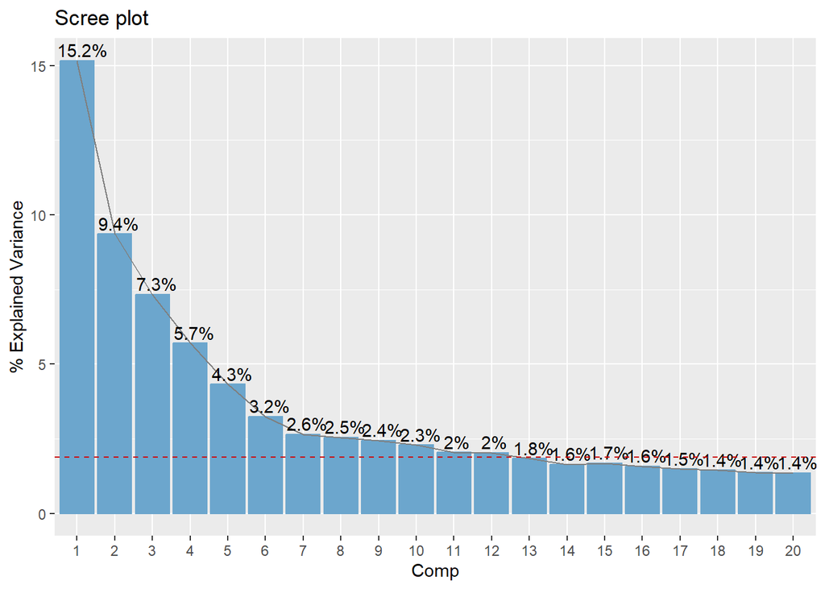

```r
pca_center <- pca(X, ncomp = NULL, algo = "nipals", scaling = "center")
pcaPlot(pca_center, type = "scree")
```

## Score plots

### Diagnóstico

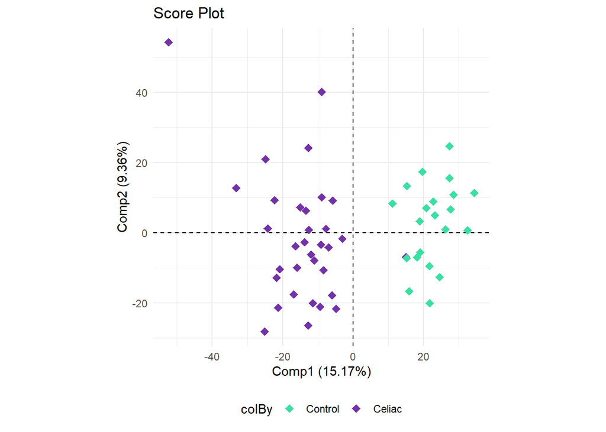

```r
pcaPlot(pca_center, type = "scores", comp = c(1, 2),
        colBy = metadata$group, ellipses = FALSE, labels = FALSE)
```

### Cohorte (training / validation)

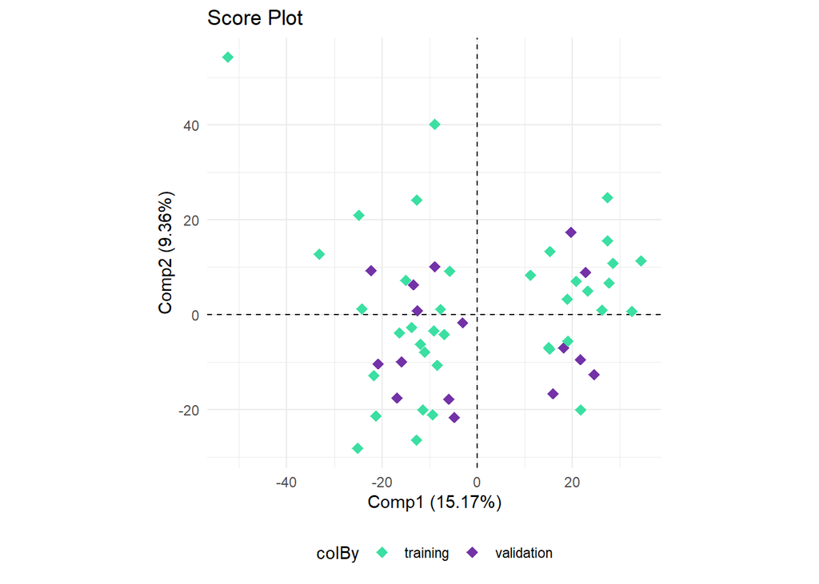

```r
pcaPlot(pca_center, type = "scores", comp = c(1, 2),
        colBy = metadata$cohort, ellipses = FALSE, labels = FALSE)
```

### Sexo

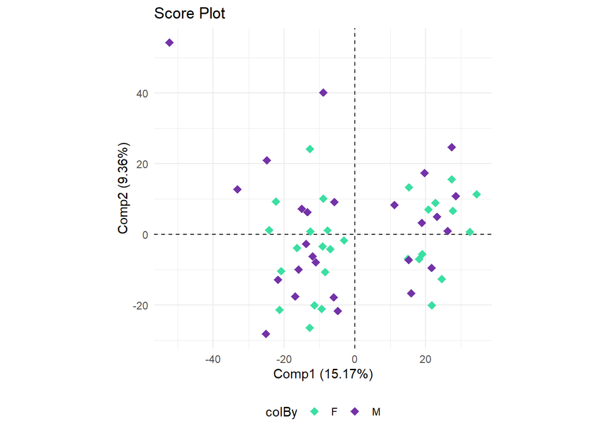

```r
pcaPlot(pca_center, type = "scores", comp = c(1, 2),
        colBy = metadata$gender, ellipses = FALSE, labels = FALSE)
```

### TTG anormal

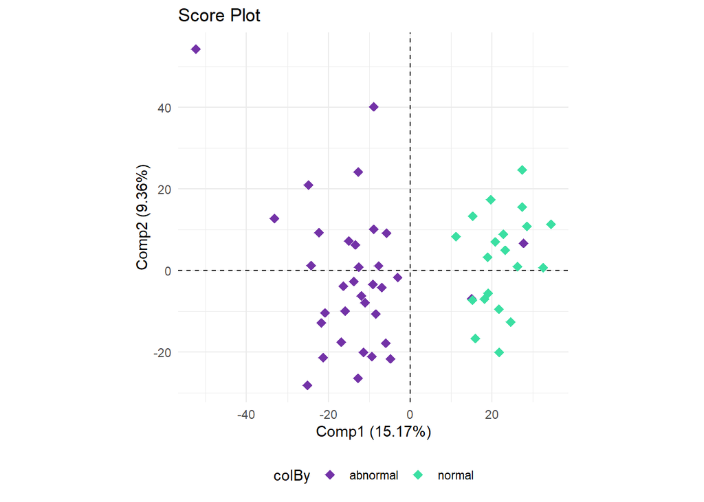

```r
pcaPlot(pca_center, type = "scores", comp = c(1, 2),
        colBy = metadata$ttg_abnormal, ellipses = FALSE, labels = FALSE)
```

### Dolor abdominal

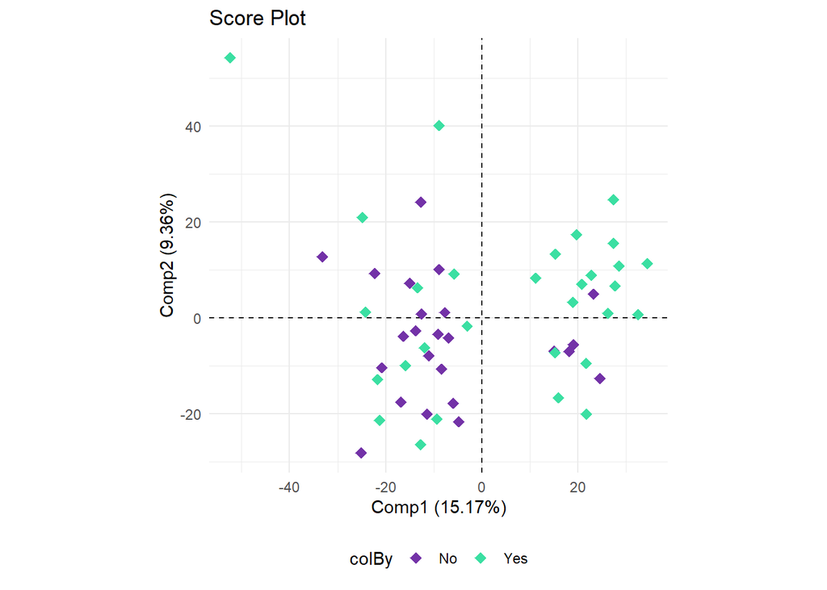

```r
pcaPlot(pca_center, type = "scores", comp = c(1, 2),
        colBy = metadata$abdominal_pain, ellipses = FALSE, labels = FALSE)
```

## Loadings — Correlation plot

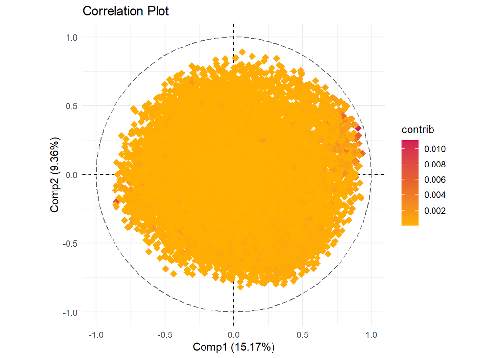

```r
pcaPlot(pca_center, type = "corr", comp = c(1, 2),
        colBy = "contrib", shape = "point", labels = FALSE, col = "hot")
```

## Loadings — Top 15 genes

Los nombres de columna de `X` están saneados (`make.names()`) antes de pasar a `pca()`. Se revierte primero al `gene_label` real mediante `safe_name_lookup`, y después se recupera el `GeneID` original y la `Description` a través de `gene_label_map`.

```r
loadings_center <- as.data.frame(pca_center$loadings) %>%
  rownames_to_column("safe_name") %>%
  as_tibble()

colnames(loadings_center)[-1] <- paste0("PC", seq_len(ncol(loadings_center) - 1))

loadings_center <- loadings_center %>%
  left_join(safe_name_lookup, by = "safe_name") %>%
  left_join(gene_label_map, by = "gene_label") %>%
  left_join(
    gene_annotation_filtered %>%
      mutate(GeneID = as.character(GeneID)) %>%
      dplyr::select(GeneID, Description),
    by = "GeneID"
  )

loadings_center %>%
  dplyr::select(gene_label, GeneID, Description, PC1, PC2) %>%
  pivot_longer(cols = starts_with("PC"), names_to = "PC", values_to = "loading") %>%
  mutate(abs_loading = abs(loading)) %>%
  group_by(PC) %>%
  arrange(desc(abs_loading), .by_group = TRUE) %>%
  slice_head(n = 15) %>%
  ungroup() %>%
  dplyr::select(PC, gene_label, GeneID, Description, loading, abs_loading) %>%
  kable(caption = "Top 15 genes con mayor contribución — PCA centrado")
```

Top 15 genes con mayor contribución — PCA centrado

| PC | gene_label | GeneID | Description | loading | abs_loading |
| --- | --- | --- | --- | --- | --- |
| PC1 | APOA1 | 335 | apolipoprotein A1 | 0.0954341 | 0.0954341 |
| PC1 | LPL | 4023 | lipoprotein lipase | -0.0863341 | 0.0863341 |
| PC1 | LCT | 3938 | lactase | 0.0793317 | 0.0793317 |
| PC1 | APOC3 | 345 | apolipoprotein C3 | 0.0724075 | 0.0724075 |
| PC1 | CYP3A4 | 1576 | cytochrome P450 family 3 subfamily A member 4 | 0.0696793 | 0.0696793 |
| PC1 | COL25A1 | 84570 | collagen type XXV alpha 1 chain | 0.0669316 | 0.0669316 |
| PC1 | HMGCS2 | 3158 | 3-hydroxy-3-methylglutaryl-CoA synthase 2 | 0.0647831 | 0.0647831 |
| PC1 | SLC5A12 | 159963 | solute carrier family 5 member 12 | 0.0641719 | 0.0641719 |
| PC1 | MS4A10 | 341116 | membrane spanning 4-domains A10 | 0.0624536 | 0.0624536 |
| PC1 | ENPP7 | 339221 | ectonucleotide pyrophosphatase/phosphodiesterase 7 | 0.0597133 | 0.0597133 |
| PC1 | LRAT | 9227 | lecithin retinol acyltransferase | 0.0585152 | 0.0585152 |
| PC1 | AQP10 | 89872 | aquaporin 10 | 0.0579785 | 0.0579785 |
| PC1 | ASAH2 | 56624 | N-acylsphingosine amidohydrolase 2 | 0.0570075 | 0.0570075 |
| PC1 | ENPP3 | 5169 | ectonucleotide pyrophosphatase/phosphodiesterase 3 | 0.0566483 | 0.0566483 |
| PC1 | GUCA2B | 2981 | guanylate cyclase activator 2B | 0.0529629 | 0.0529629 |
| PC2 | APOA1 | 335 | apolipoprotein A1 | 0.0454325 | 0.0454325 |
| PC2 | ENPP7 | 339221 | ectonucleotide pyrophosphatase/phosphodiesterase 7 | 0.0408414 | 0.0408414 |
| PC2 | OR11H2 | 79334 | olfactory receptor family 11 subfamily H member 2 | 0.0394180 | 0.0394180 |
| PC2 | HK2 | 3099 | hexokinase 2 | -0.0391225 | 0.0391225 |
| PC2 | CLIC6 | 54102 | chloride intracellular channel 6 | -0.0363207 | 0.0363207 |
| PC2 | GP2 | 2813 | glycoprotein 2 | -0.0362668 | 0.0362668 |
| PC2 | CD9 | 928 | CD9 molecule | -0.0362249 | 0.0362249 |
| PC2 | CCL20 | 6364 | C-C motif chemokine ligand 20 | -0.0357112 | 0.0357112 |
| PC2 | APH1B | 83464 | aph-1 homolog B, gamma-secretase subunit | -0.0349058 | 0.0349058 |
| PC2 | SFRP4 | 6424 | secreted frizzled related protein 4 | -0.0344078 | 0.0344078 |
| PC2 | SERPINA3 | 12 | serpin family A member 3 | -0.0339527 | 0.0339527 |
| PC2 | LCT | 3938 | lactase | 0.0338728 | 0.0338728 |
| PC2 | PDE6D | 5147 | phosphodiesterase 6D | -0.0335831 | 0.0335831 |
| PC2 | GUCA2B | 2981 | guanylate cyclase activator 2B | 0.0324884 | 0.0324884 |
| PC2 | SRXN1 | 140809 | sulfiredoxin 1 | 0.0316908 | 0.0316908 |

# Detección de muestras anómalas

Se fija el número de componentes a K=2 ya que, con estas dos componentes los datos se separan bien entre grupos. Se detectan anómalos mediante dos criterios complementarios: RSS (Residual Sum of Squares) y T² de Hotelling.

```r
K <- 2
pca_center <- pca(X, ncomp = K, algo = "nipals", scaling = "center")
```

```r
par(mfrow = c(1, 2))

pca_cen_out_RSS <- pcaOutliers(pca_center, ncomp = pca_center$ncomp,method = "RSS", conf = 0.95)
pca_cen_out_T2  <- pcaOutliers(pca_center, ncomp = pca_center$ncomp,method = "T2",  conf = 0.95)
```

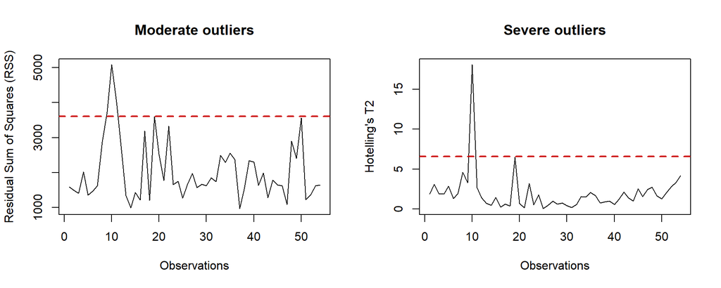

```r
par(mfrow = c(1, 1))
```

```r
pca_cen_moderate <- sort(
  pca_cen_out_RSS$RSS[pca_cen_out_RSS$ModerateOutliers],
  decreasing = TRUE
)

pca_cen_severe <- sort(
  pca_cen_out_T2$T2[pca_cen_out_T2$SevereOutliers],
  decreasing = TRUE
)

cat("Anómalos moderados (RSS) al 95 :\n"); print(pca_cen_moderate)
```

```
## Anómalos moderados (RSS) al 95 :
```

```
## GSM3814349 GSM3814350 GSM3814348
##   5083.627   4019.886   3738.931
```

```r
cat("\nAnómalos severos (T²) al 95 :\n");   print(pca_cen_severe)
```

```
##
## Anómalos severos (T²) al 95 :
```

```
## GSM3814349
##   18.08436
```

```r
par(mfrow = c(1, 2))

pca_cen_out_RSS_99 <- pcaOutliers(pca_center, ncomp = pca_center$ncomp,method = "RSS", conf = 0.99)
pca_cen_out_T2_99  <- pcaOutliers(pca_center, ncomp = pca_center$ncomp,method = "T2",  conf = 0.99)
```

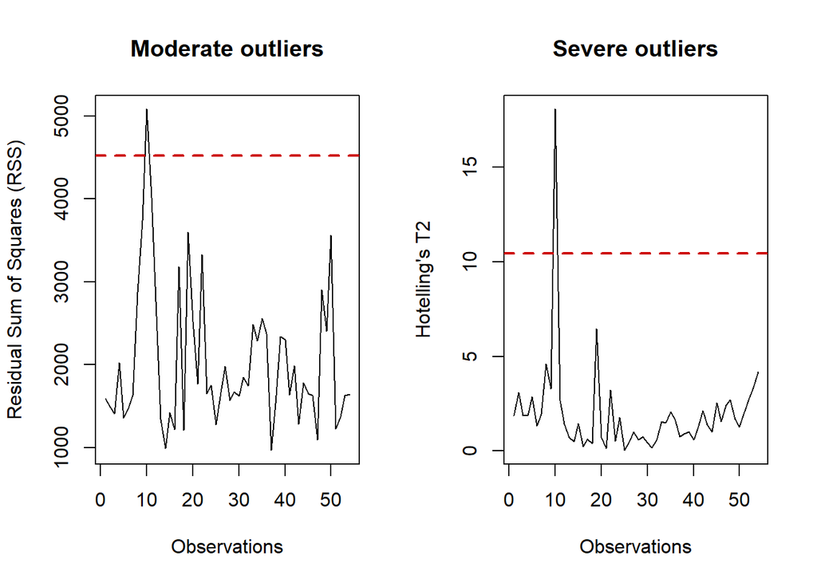

```r
par(mfrow = c(1, 1))
```

```r
cen_moderate_99 <- sort(pca_cen_out_RSS_99$RSS[pca_cen_out_RSS_99$ModerateOutliers],
                    decreasing = TRUE)
cen_severe_99   <- sort(pca_cen_out_T2_99$T2[pca_cen_out_T2_99$SevereOutliers],
                    decreasing = TRUE)

cat("Moderados (RSS) al 99 :\n"); print(cen_moderate_99)
```

```
## Moderados (RSS) al 99 :
```

```
## GSM3814349
##   5083.627
```

```r
cat("Severos   (T²) al 99 :\n");  print(cen_severe_99)
```

```
## Severos   (T²) al 99 :
```

```
## GSM3814349
##   18.08436
```

```r
pca_cen_mod_contrib_99 <- outlierContrib(pca_center, pca_cen_out_RSS_99)
```

```
## There are no severe outliers in the data or they were not computed.
```

```
## There are 1 moderate outliers in the data provided.
```

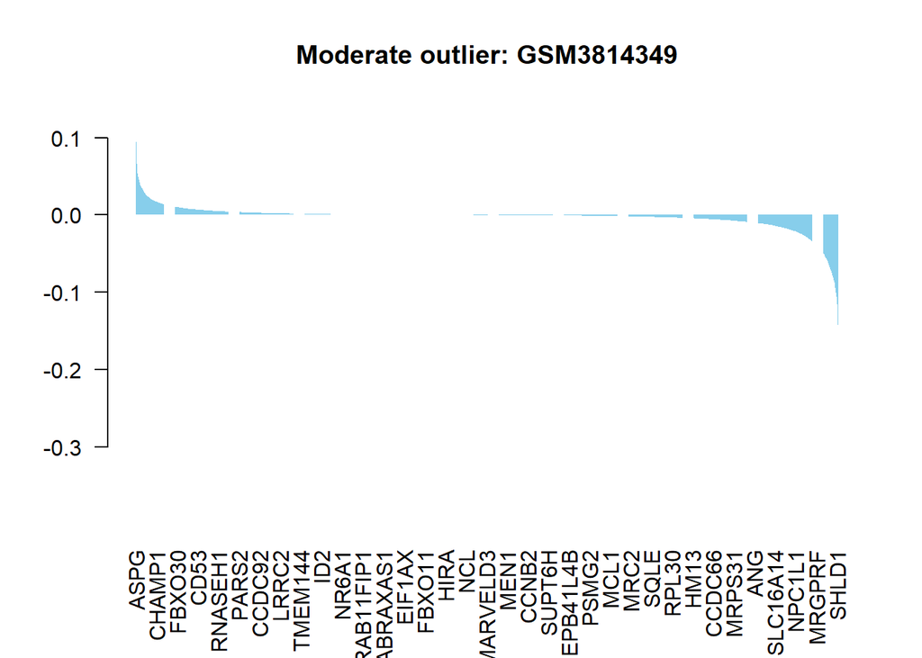

```r
pca_cen_sev_contrib_99 <- outlierContrib(pca_center, pca_cen_out_T2_99)
```

```
## There are 1 severe outliers in the data provided.
```

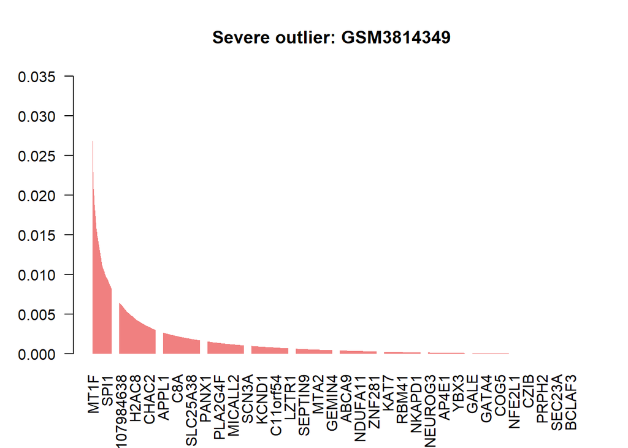

```
## There are no moderate outliers in the data or they were not computed.
```

```r
get_top_contrib_list <- function(contrib_matrix, lookup, n = 10) {
  lapply(rownames(contrib_matrix), function(sample_name) {
    row <- contrib_matrix[sample_name, ]
    top <- row[order(abs(row), decreasing = TRUE)][1:n]
    tibble(
      sample_id = sample_name,
      safe_name = names(top),
      contribution = as.numeric(top)
    ) %>%
      left_join(lookup, by = "safe_name") %>%
      dplyr::select(sample_id, gene_label, contribution)
  })
}

top10_cen_moderate <- get_top_contrib_list(pca_cen_mod_contrib_99$contribRSS, safe_name_lookup)

top10_cen_moderate
```

[output not shown]

```r
top10_cen_severe <- get_top_contrib_list(pca_cen_sev_contrib_99$contribT2, safe_name_lookup)

top10_cen_severe
```

```
## [[1]]
## # A tibble: 10 × 3
##    sample_id  gene_label contribution
##    <chr>      <chr>             <dbl>
##  1 GSM3814349 MT1F             0.0353
##  2 GSM3814349 CRISPLD2         0.0324
##  3 GSM3814349 ESYT1            0.0323
##  4 GSM3814349 SCGN             0.0320
##  5 GSM3814349 LPL              0.0318
##  6 GSM3814349 TTC8             0.0299
##  7 GSM3814349 EDIL3            0.0292
##  8 GSM3814349 GC               0.0276
##  9 GSM3814349 SGPP1            0.0268
## 10 GSM3814349 APIP             0.0268
```

# PCA — Escalado estándar

Se prioriza el escalado estándar para los análisis posteriores (detección de anómalos): en RNA-seq log-transformado la varianza no es homogénea entre genes, y sin escalar, los genes muy expresados dominarían las primeras componentes independientemente de su relevancia biológica.

## Cálculo y scree plot

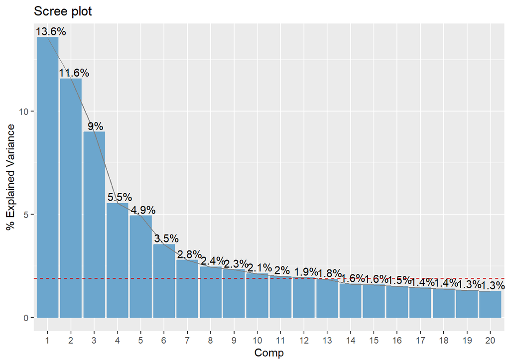

```r
pca_std <- pca(X, ncomp = NULL, algo = "nipals", scaling = "standard")
pcaPlot(pca_std, type = "scree")
```

## Score plots

### Diagnóstico

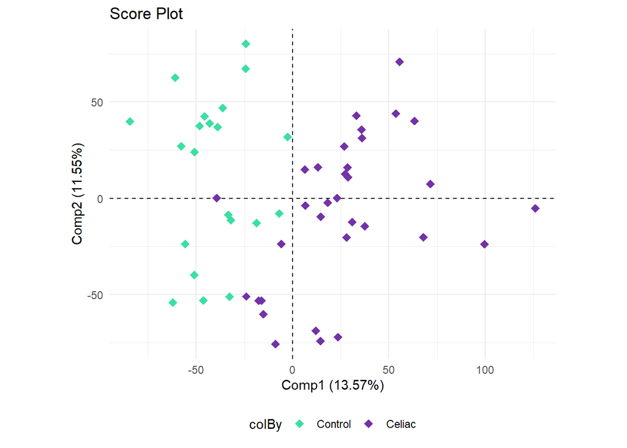

```r
pcaPlot(pca_std, type = "scores", comp = c(1, 2),
        colBy = metadata$group, ellipses = FALSE, labels = FALSE)
```

### Cohorte (training / validation)

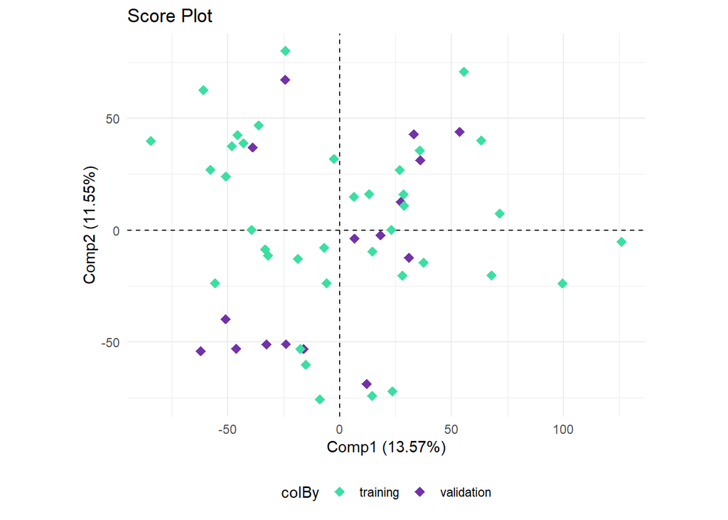

```r
pcaPlot(pca_std, type = "scores", comp = c(1, 2),
        colBy = metadata$cohort, ellipses = FALSE, labels = FALSE)
```

### Sexo

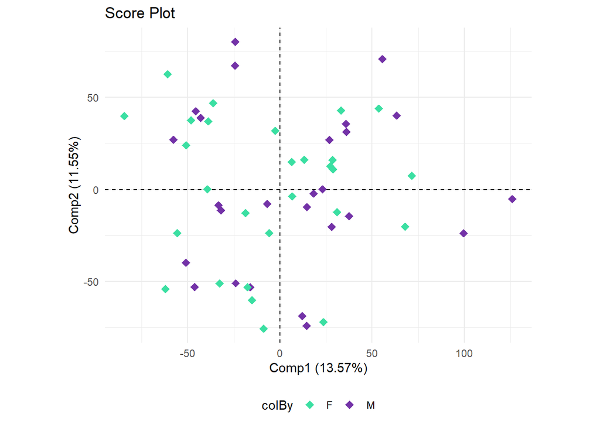

```r
pcaPlot(pca_std, type = "scores", comp = c(1, 2),
        colBy = metadata$gender, ellipses = FALSE, labels = FALSE)
```

### TTG anormal

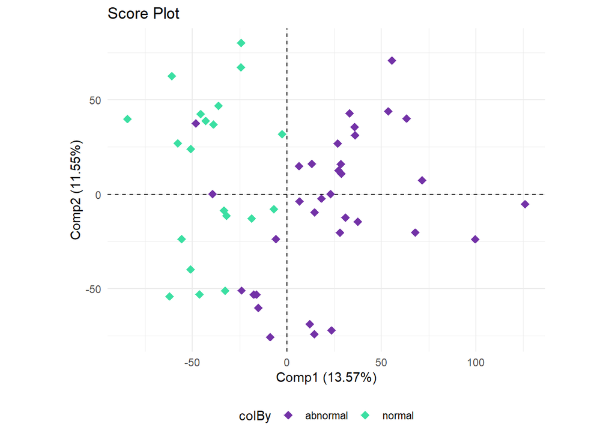

```r
pcaPlot(pca_std, type = "scores", comp = c(1, 2),
        colBy = metadata$ttg_abnormal, ellipses = FALSE, labels = FALSE)
```

### Dolor abdominal

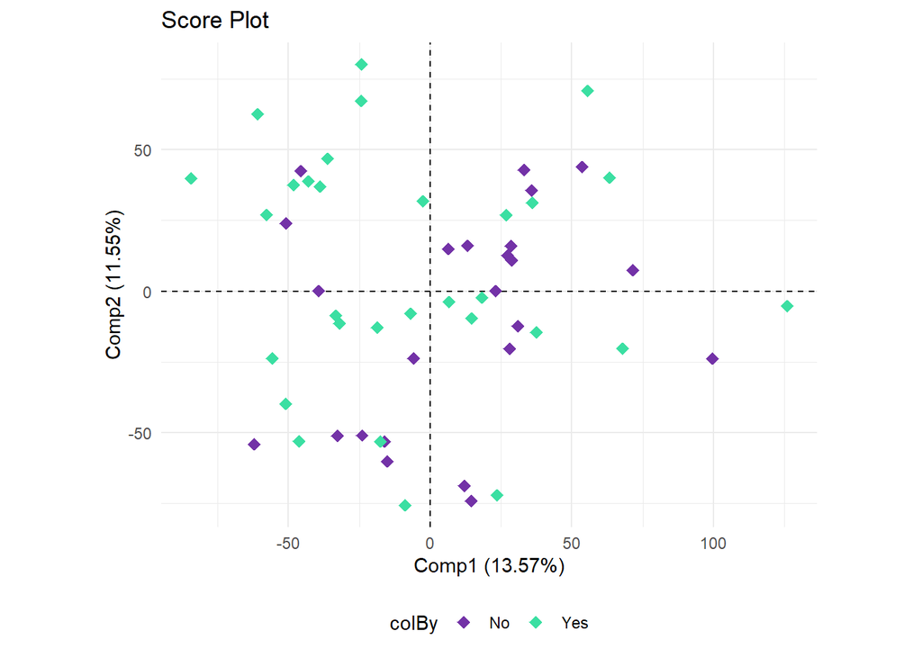

```r
pcaPlot(pca_std, type = "scores", comp = c(1, 2),
        colBy = metadata$abdominal_pain, ellipses = FALSE, labels = FALSE)
```

## Score plots — PC3-PC4

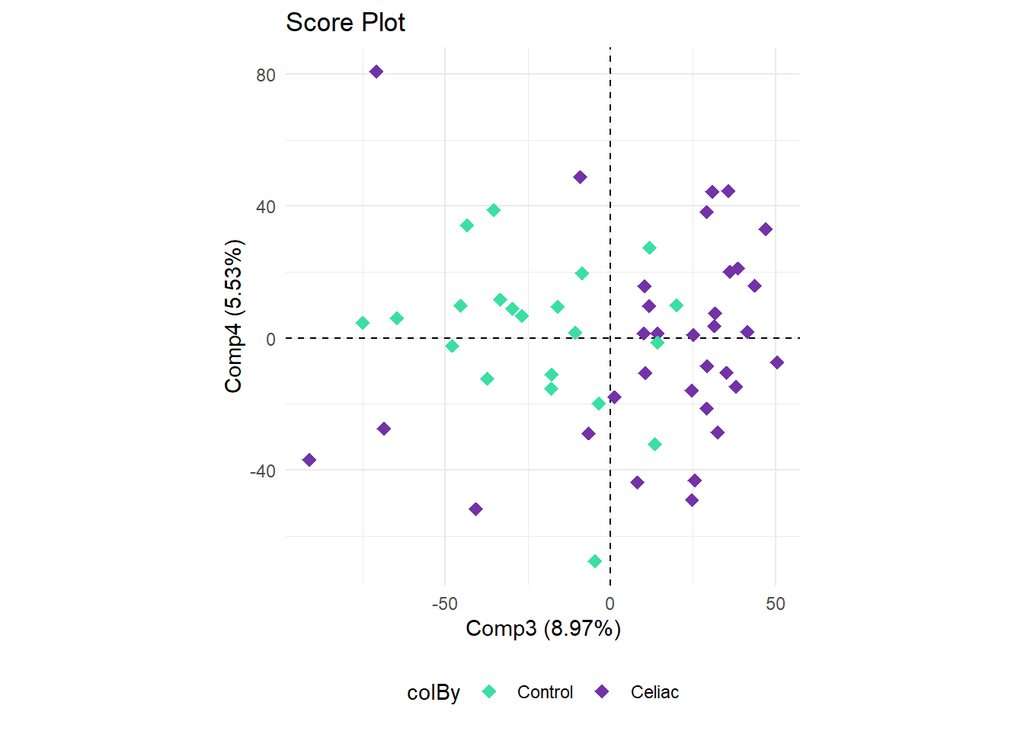

```r
pcaPlot(pca_std, type = "scores", comp = c(3, 4),
        colBy = metadata$group, ellipses = FALSE, labels = FALSE)
```

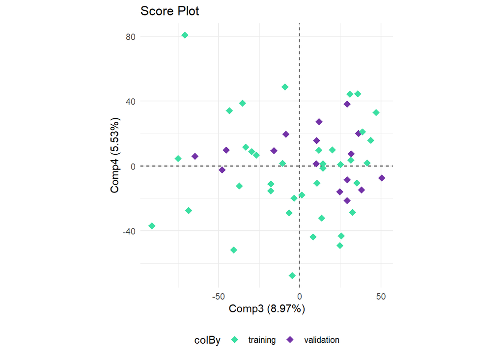

```r
pcaPlot(pca_std, type = "scores", comp = c(3, 4),
        colBy = metadata$cohort, ellipses = FALSE, labels = FALSE)
```

## Score plots — PC5-PC6

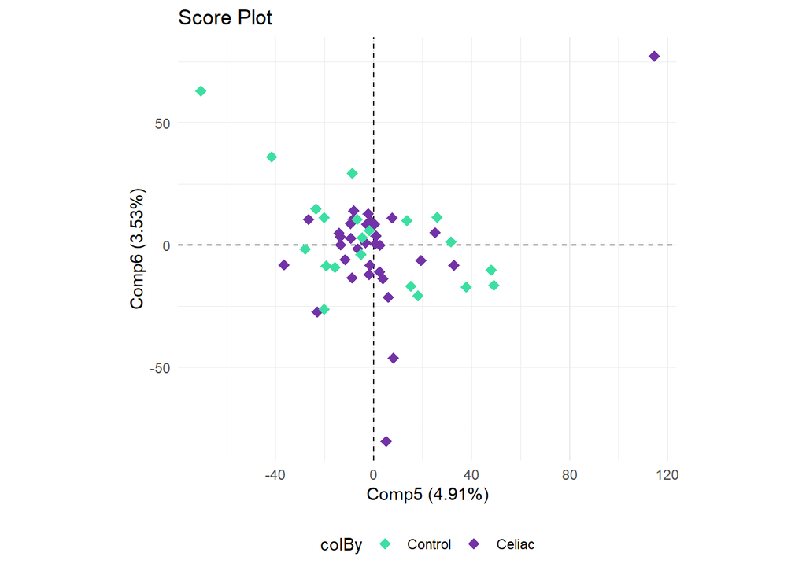

```r
pcaPlot(pca_std, type = "scores", comp = c(5, 6),
        colBy = metadata$group, ellipses = FALSE, labels = FALSE)
```

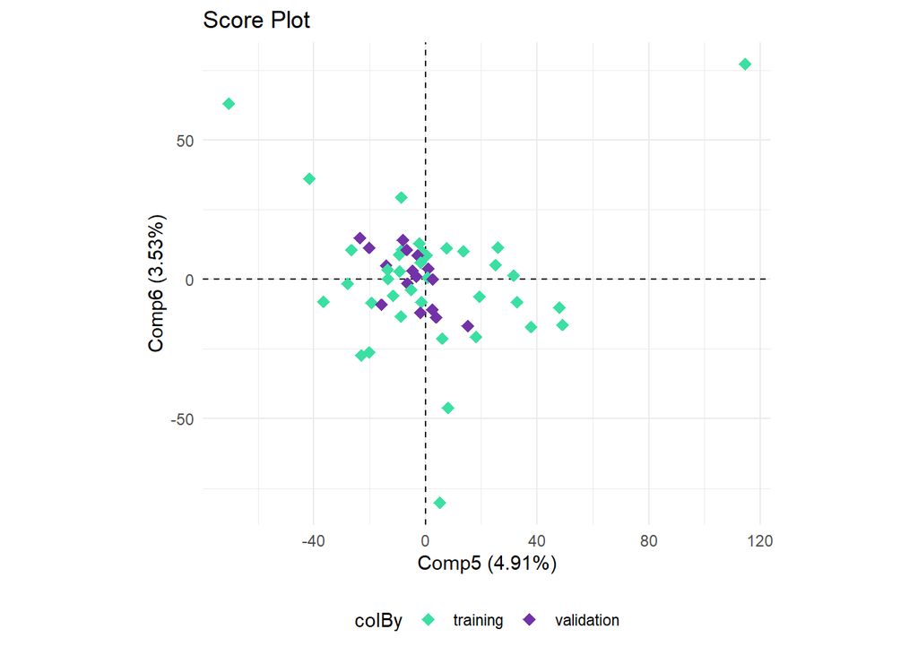

```r
pcaPlot(pca_std, type = "scores", comp = c(5, 6),
        colBy = metadata$cohort, ellipses = FALSE, labels = FALSE)
```

## Loadings — Correlation plot

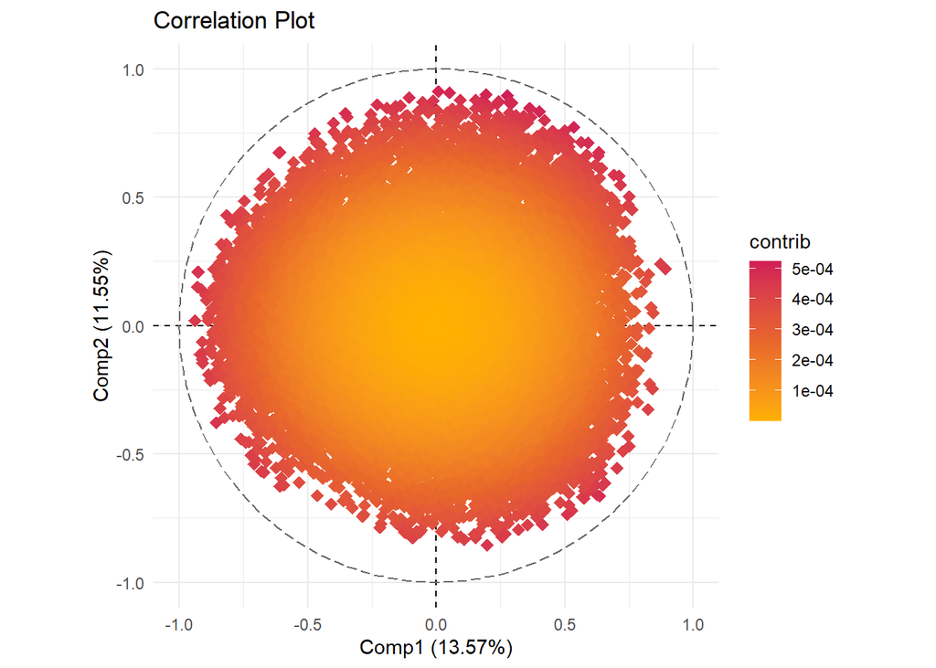

```r
pcaPlot(pca_std, type = "corr", comp = c(1, 2),
        colBy = "contrib", shape = "point", labels = FALSE, col = "hot")
```

## Loadings — Top 15 genes

```r
loadings_std <- as.data.frame(pca_std$loadings) %>%
  rownames_to_column("safe_name") %>%
  as_tibble()

colnames(loadings_std)[-1] <- paste0("PC", seq_len(ncol(loadings_std) - 1))

loadings_std <- loadings_std %>%
  left_join(safe_name_lookup, by = "safe_name") %>%
  left_join(gene_label_map, by = "gene_label") %>%
  left_join(
    gene_annotation_filtered %>%
      mutate(GeneID = as.character(GeneID)) %>%
      dplyr::select(GeneID, Description),
    by = "GeneID"
  )

loadings_std %>%
  dplyr::select(gene_label, GeneID, Description, PC1, PC2) %>%
  pivot_longer(cols = starts_with("PC"), names_to = "PC", values_to = "loading") %>%
  mutate(abs_loading = abs(loading)) %>%
  group_by(PC) %>%
  arrange(desc(abs_loading), .by_group = TRUE) %>%
  slice_head(n = 15) %>%
  ungroup() %>%
  dplyr::select(PC, gene_label, GeneID, Description, loading, abs_loading) %>%
  kable(caption = "Top 15 genes con mayor contribución — PCA estándar")
```

Top 15 genes con mayor contribución — PCA estándar

| PC | gene_label | GeneID | Description | loading | abs_loading |
| --- | --- | --- | --- | --- | --- |
| PC1 | TSPAN3 | 10099 | tetraspanin 3 | -0.0212862 | 0.0212862 |
| PC1 | EIF4EBP2 | 1979 | eukaryotic translation initiation factor 4E binding protein 2 | -0.0210771 | 0.0210771 |
| PC1 | FTH1 | 2495 | ferritin heavy chain 1 | -0.0210012 | 0.0210012 |
| PC1 | BEST1 | 7439 | bestrophin 1 | -0.0209991 | 0.0209991 |
| PC1 | RPS3A | 6189 | ribosomal protein S3A | -0.0208387 | 0.0208387 |
| PC1 | MAOB | 4129 | monoamine oxidase B | -0.0207580 | 0.0207580 |
| PC1 | RPL13A | 23521 | ribosomal protein L13a | -0.0206402 | 0.0206402 |
| PC1 | HADHB | 3032 | hydroxyacyl-CoA dehydrogenase trifunctional multienzyme complex subunit beta | -0.0206325 | 0.0206325 |
| PC1 | TSPAN7 | 7102 | tetraspanin 7 | -0.0206270 | 0.0206270 |
| PC1 | EEF1A1 | 1915 | eukaryotic translation elongation factor 1 alpha 1 | -0.0206050 | 0.0206050 |
| PC1 | PRR15 | 222171 | proline rich 15 | -0.0203416 | 0.0203416 |
| PC1 | FUCA1 | 2517 | alpha-L-fucosidase 1 | -0.0202728 | 0.0202728 |
| PC1 | NCOA3 | 8202 | nuclear receptor coactivator 3 | 0.0202071 | 0.0202071 |
| PC1 | NBR1 | 4077 | NBR1 autophagy cargo receptor | -0.0201341 | 0.0201341 |
| PC1 | SELENOP | 6414 | selenoprotein P | -0.0201279 | 0.0201279 |
| PC2 | EMG1 | 10436 | EMG1 N1-specific pseudouridine methyltransferase | 0.0223934 | 0.0223934 |
| PC2 | ECHS1 | 1892 | enoyl-CoA hydratase, short chain 1 | 0.0222897 | 0.0222897 |
| PC2 | MAP2K2 | 5605 | mitogen-activated protein kinase kinase 2 | 0.0220895 | 0.0220895 |
| PC2 | TMUB1 | 83590 | transmembrane and ubiquitin like domain containing 1 | 0.0220141 | 0.0220141 |
| PC2 | ATP5MC2 | 517 | ATP synthase membrane subunit c locus 2 | 0.0218366 | 0.0218366 |
| PC2 | MAPK3 | 5595 | mitogen-activated protein kinase 3 | 0.0215701 | 0.0215701 |
| PC2 | HADHA | 3030 | hydroxyacyl-CoA dehydrogenase trifunctional multienzyme complex subunit alpha | 0.0215682 | 0.0215682 |
| PC2 | TNFRSF1A | 7132 | TNF receptor superfamily member 1A | 0.0215183 | 0.0215183 |
| PC2 | ZDHHC9 | 51114 | zinc finger DHHC-type palmitoyltransferase 9 | 0.0215118 | 0.0215118 |
| PC2 | FAM3A | 60343 | FAM3 metabolism regulating signaling molecule A | 0.0214681 | 0.0214681 |
| PC2 | RAB7A | 7879 | RAB7A, member RAS oncogene family | 0.0214600 | 0.0214600 |
| PC2 | SH3GL1 | 6455 | SH3 domain containing GRB2 like 1, endophilin A2 | 0.0213768 | 0.0213768 |
| PC2 | TXN2 | 25828 | thioredoxin 2 | 0.0213489 | 0.0213489 |
| PC2 | PPP6R1 | 22870 | protein phosphatase 6 regulatory subunit 1 | 0.0213265 | 0.0213265 |
| PC2 | CHMP4B | 128866 | charged multivesicular body protein 4B | 0.0211989 | 0.0211989 |

# Detección de muestras anómalas

Se fija el número de componentes a K=2, ya que con estas dos componentes los datos se separan bien entre grupos. Se detectan anómalos mediante dos criterios complementarios: RSS (Residual Sum of Squares) y T² de Hotelling.

```r
K <- 2
pca_std <- pca(X, ncomp = K, algo = "nipals", scaling = "standard")
```

```r
par(mfrow = c(1, 2))

pca_out_RSS <- pcaOutliers(pca_std, ncomp = pca_std$ncomp,method = "RSS", conf = 0.95)
pca_out_T2  <- pcaOutliers(pca_std, ncomp = pca_std$ncomp,method = "T2",  conf = 0.95)
```

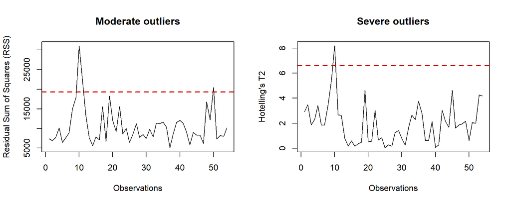

```r
par(mfrow = c(1, 1))
```

```r
pca_moderate <- sort(
  pca_out_RSS$RSS[pca_out_RSS$ModerateOutliers],
  decreasing = TRUE
)

pca_severe <- sort(
  pca_out_T2$T2[pca_out_T2$SevereOutliers],
  decreasing = TRUE
)

cat("Anómalos moderados (RSS) al 95 :\n"); print(pca_moderate)
```

```
## Anómalos moderados (RSS) al 95 :
```

```
## GSM3814349 GSM3814350 GSM3814389
##   31051.95   21918.88   20436.15
```

```r
cat("\nAnómalos severos (T²) al 95 :\n");   print(pca_severe)
```

```
##
## Anómalos severos (T²) al 95 :
```

```
## GSM3814349
##   8.182259
```

```r
par(mfrow = c(1, 2))

pca_out_RSS_99 <- pcaOutliers(pca_std, ncomp = pca_std$ncomp,method = "RSS", conf = 0.99)
pca_out_T2_99  <- pcaOutliers(pca_std, ncomp = pca_std$ncomp,method = "T2",  conf = 0.99)
```

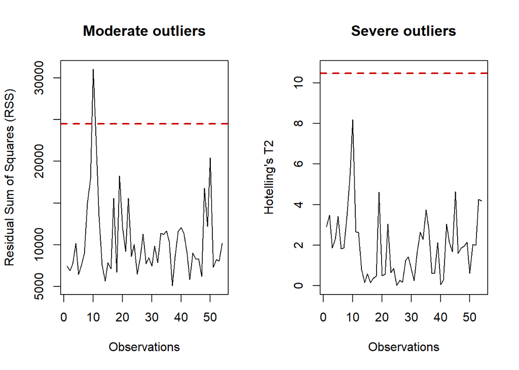

```r
par(mfrow = c(1, 1))
```

```r
moderate_99 <- sort(pca_out_RSS_99$RSS[pca_out_RSS_99$ModerateOutliers],
                    decreasing = TRUE)
severe_99   <- sort(pca_out_T2_99$T2[pca_out_T2_99$SevereOutliers],
                    decreasing = TRUE)

cat("Moderados (RSS) al 99 :\n"); print(moderate_99)
```

```
## Moderados (RSS) al 99 :
```

```
## GSM3814349
##   31051.95
```

```r
cat("Severos   (T²) al 99 :\n");  print(severe_99)
```

```
## Severos   (T²) al 99 :
```

```
## named numeric(0)
```

```r
pca_mod_contrib_99 <- outlierContrib(pca_std, pca_out_RSS_99)
```

```
## There are no severe outliers in the data or they were not computed.
```

```
## There are 1 moderate outliers in the data provided.
```

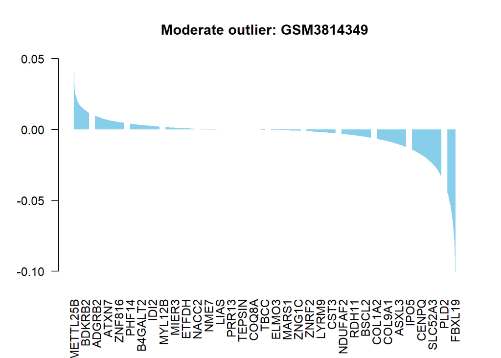

```r
pca_sev_contrib_99 <- outlierContrib(pca_std, pca_out_T2_99)
```

```
## There are no severe outliers in the data or they were not computed.
```

```
## There are no moderate outliers in the data or they were not computed.
```

```r
get_top_contrib_list <- function(contrib_matrix, lookup, n = 10) {
  lapply(rownames(contrib_matrix), function(sample_name) {
    row <- contrib_matrix[sample_name, ]
    top <- row[order(abs(row), decreasing = TRUE)][1:n]
    tibble(
      sample_id = sample_name,
      safe_name = names(top),
      contribution = as.numeric(top)
    ) %>%
      left_join(lookup, by = "safe_name") %>%
      dplyr::select(sample_id, gene_label, contribution)
  })
}

top10_moderate <- get_top_contrib_list(pca_mod_contrib_99$contribRSS, safe_name_lookup)

top10_moderate
```

```
## [[1]]
## # A tibble: 10 × 3
##    sample_id  gene_label contribution
##    <chr>      <chr>             <dbl>
##  1 GSM3814349 TMEM138         -0.110
##  2 GSM3814349 DUSP28          -0.108
##  3 GSM3814349 SSBP4           -0.107
##  4 GSM3814349 ARL3            -0.102
##  5 GSM3814349 OXSM            -0.102
##  6 GSM3814349 TRMT2A          -0.100
##  7 GSM3814349 HAUS1           -0.0992
##  8 GSM3814349 KIAA1671        -0.0979
##  9 GSM3814349 POP1            -0.0978
## 10 GSM3814349 GAS7            -0.0974
```

```r
top10_severe <- get_top_contrib_list(pca_sev_contrib_99$contribT2, safe_name_lookup)

top10_severe
```

```
## list()
```